# 📘 Inventory Optimization Report – Athers Food Inc.

## 1. Introduction

Athers Food Inc., a leader in shelf-stable foods, has experienced a paradoxical trend: rising revenues but falling profits. This prompted a supply chain audit requested by the new COO, Samantha, to evaluate the firm’s inventory policy.

This report leverages data from 2019 to 2021, and forecasts for 2022, to:

- Model the demand accurately
- Reverse engineer the current inventory system
- Evaluate its sustainability
- Compare with Economic Order Quantity (EOQ)
- Introduce a dynamic inventory policy
- Offer strategic managerial insights

## 2. Demand Modeling

The daily demand follows a Negative Binomial Distribution, with added trends:

- Holiday season adds +70 units/day in November & December.
- Annual increase of +10 units/day since 2020.

### Demand Formula:

Let $( D_{\text{base}} \sim \text{NegBin}(r = 5, p = 0.02) )$ $  
D_t = D_{\text{base}} + H_t + Y_t  
$ Where:

- $( H_t = 70 ) if ( t \in \text{Nov or Dec} )$, otherwise 0.
- $( Y_t = 10 \cdot (\text{year} - 2019) )$

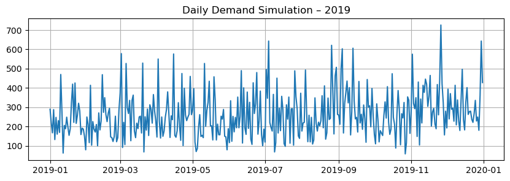

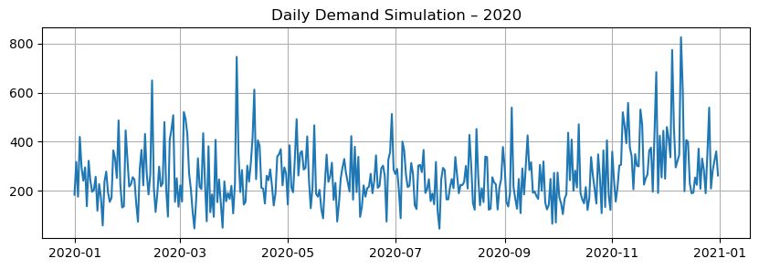

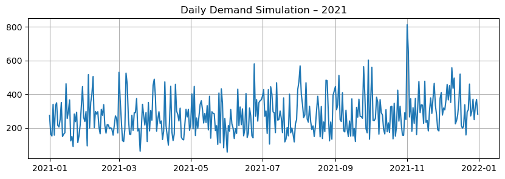

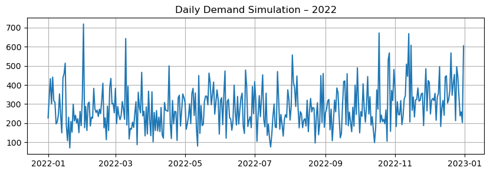

```python
import numpy as np
import pandas as pd
import matplotlib.pyplot as plt
from scipy.stats import nbinom

np.random.seed(42)

years = [2019, 2020, 2021, 2022]
holiday_months = [11, 12]
r, p = 5, 0.02

demand_data = []
for year in years:
    start_date = pd.Timestamp(f"{year}-01-01")
    end_date = pd.Timestamp(f"{year}-12-31")
    dates = pd.date_range(start=start_date, end=end_date)
    yearly_increase = 10 * (year - 2019)
    for date in dates:
        base_demand = nbinom.rvs(r, p)
        holiday_increase = 70 if date.month in holiday_months else 0
        total_demand = base_demand + holiday_increase + yearly_increase
        demand_data.append({
            "date": date, "year": year,
            "total_demand": total_demand
        })

df_demand = pd.DataFrame(demand_data)
for year in years:
    plt.figure(figsize=(10, 3))
    plt.plot(df_demand[df_demand['year'] == year]['date'],
             df_demand[df_demand['year'] == year]['total_demand'])
    plt.title(f'Daily Demand Simulation – {year}')
    plt.grid(True)
    plt.show()
```

## 📐 3. Mathematical Models and Equations

### 🧮 1. Demand Modeling

Model daily demand $( D_t )$ as a combination of:

$  
Y_t = 10 \cdot (y - 2019) \quad \text{(for year } y \in {2019, 2020, 2021, 2022})  
$

#### 🔢 Final Demand Equation:

## $ D_t = D_{\text{base}} + H_t + Y_t $

### 🏭 2. Economic Order Quantity (EOQ)

$  
EOQ = Q^* = \sqrt{\frac{2DS}{H}}  
$ Where:

- $( D )$: Annual demand (units/year)
- $( S = 1200 )$: Setup cost per order
- $( H = 0.25 \times 365 = 91.25 )$: Annual holding cost per unit

### 📦 3. Inventory Cost Components

- **Setup Cost** $  
  = N_o \cdot S  
  $
- **Production Cost** $  
  = D \cdot c \quad \text{where } c = 1.50  
  $
- **Holding Cost** $  
  = \sum_{t=1}^{365} I_t \cdot h \quad \text{where } h = 0.25  
  $
- **Revenue** $  
  = \sum_{t=1}^{365} \min(D_t, I_t) \cdot P \quad \text{where } P = 35.50  
  $
- **Total Profit** $  
  = \text{Revenue} - (\text{Setup Cost} + \text{Production Cost} + \text{Holding Cost})  
  $

### 📉 4. Risk vs Profit Analysis (EOQ + Safety Stock)

- **Safety Stock**: $  
  SS = Z \cdot \sigma \cdot \sqrt{L}  
  $ Where:
- $( Z )$: Z-score for desired service level (e.g., 1.28 for 90%)
- $( \sigma )$: Std. deviation of daily demand
- $( L = 9 )$: Lead time
- **Adjusted Reorder Point**: $  
  ROP = \frac{Q}{2} + SS  
  $

### 🔄 5. Flexible (Continuous Review) Inventory Policy

- **Reorder Point**: $  
  ROP = D \cdot L + Z \cdot \sigma \cdot \sqrt{L}  
  $
- **Order Quantity**: $  
  Q_t = \max(0, (ROP + SS) - I_t)  
  $ This model allows orders of any size at any time, optimizing both responsiveness and inventory levels.

## 4. Reverse Engineering the Current Inventory Policy

Based on the provided inventory logs, infer that production batches arrive monthly and are requested 9 days earlier.

### Policy Characteristics:

- **Batch Size**: ~7,900 units
- **Reorder Frequency**: Monthly (1st of each month)
- **Lead Time**: 9 days
- **No dynamic adaptation to demand** — same order size each time.

```python
inventory_df = pd.read_csv('inventory.csv', parse_dates=['Day'])
inventory_df.rename(columns={'Day': 'date', 'Demand': 'demand', 'Inventory': 'inventory'}, inplace=True)
inventory_df = inventory_df.sort_values(by='date').reset_index(drop=True)
inventory_df['prev_inventory'] = inventory_df['inventory'].shift(1)
inventory_df['inventory_change'] = inventory_df['inventory'] - inventory_df['prev_inventory']
inventory_df['production_arrival'] = inventory_df['inventory_change'] > 0
inventory_df.head(10)
```

|  | date | demand | inventory | prev_inventory | inventory_change | production_arrival |
| --- | --- | --- | --- | --- | --- | --- |
| 0 | 2019-01-01 | 340 | 4660 | NaN | NaN | False |
| 1 | 2019-01-02 | 336 | 4324 | 4660.0 | -336.0 | False |
| 2 | 2019-01-03 | 177 | 4147 | 4324.0 | -177.0 | False |
| 3 | 2019-01-04 | 172 | 3975 | 4147.0 | -172.0 | False |
| 4 | 2019-01-05 | 513 | 3462 | 3975.0 | -513.0 | False |
| 5 | 2019-01-06 | 141 | 3321 | 3462.0 | -141.0 | False |
| 6 | 2019-01-07 | 307 | 3014 | 3321.0 | -307.0 | False |
| 7 | 2019-01-08 | 163 | 2851 | 3014.0 | -163.0 | False |
| 8 | 2019-01-09 | 259 | 2592 | 2851.0 | -259.0 | False |
| 9 | 2019-01-10 | 189 | 10553 | 2592.0 | 7961.0 | True |

## 5. Simulating the Current Inventory Policy for 2022

Simulate fixed monthly batches of size ~7,900 with 9-day lead time using the 2022 demand data.

```python
df_2022 = df_demand[df_demand['year'] == 2022].copy().reset_index(drop=True)

initial_inventory = 5000
setup_cost = 1200
unit_cost = 1.5
holding_cost = 0.25
unit_price = 35.5

batch_size = 7900
reorder_days = pd.date_range("2022-01-01", "2022-12-31", freq='MS')
arrival_days = reorder_days + pd.Timedelta(days=9)
arrival_set = set(arrival_days)

inventory = initial_inventory
rev = hold_cost = setup_total = prod_total = stockouts = 0

for _, row in df_2022.iterrows():
    if row['date'] in arrival_set:
        inventory += batch_size
        setup_total += setup_cost
        prod_total += batch_size * unit_cost
    demand = row['total_demand']
    fulfilled = min(inventory, demand)
    stockouts += max(0, demand - inventory)
    inventory -= fulfilled
    rev += fulfilled * unit_price
    hold_cost += inventory * holding_cost

{
    "Revenue": rev,
    "Setup Cost": setup_total,
    "Production Cost": prod_total,
    "Holding Cost": hold_cost,
    "Stockouts": stockouts
}
```

```
{'Revenue': 3542900.0,
 'Setup Cost': 14400,
 'Production Cost': 142200.0,
 'Holding Cost': 463177.5,
 'Stockouts': 3158}
```

## 6. Economic Order Quantity (EOQ) Modeling

Apply the classical EOQ formula for each year: $  
EOQ = \sqrt{\frac{2DS}{H}}  
$ Where:

- (D) = Annual demand (units)
- (S = 1200) = Setup cost per order
- $(H = 0.25 \times 365 = 91.25)$ = Annual holding cost per unit

```python
setup_cost = 1200
holding_cost_annual = 0.25 * 365

eoq_results = []
for year in [2019, 2020, 2021, 2022]:
    df = df_demand[df_demand['year'] == year]
    D = df['total_demand'].sum()
    EOQ = int(np.sqrt((2 * D * setup_cost) / holding_cost_annual))
    eoq_results.append({'Year': year, 'Total Demand': D, 'EOQ': EOQ})

pd.DataFrame(eoq_results)
```

|  | Year | Total Demand | EOQ |
| --- | --- | --- | --- |
| 0 | 2019 | 96241 | 1590 |
| 1 | 2020 | 96927 | 1596 |
| 2 | 2021 | 101056 | 1630 |
| 3 | 2022 | 102958 | 1645 |

## 7. EOQ Policy Simulation

Simulate the EOQ policy assuming:

- Reorders happen when inventory falls below (EOQ/2)
- Orders arrive after a 9-day lead time
- EOQ is recalculated annually

```python
def simulate_eoq(df, eoq):
    inventory = 5000
    delay = 9
    reorder_point = eoq // 2
    pending_orders = []

    rev = hold = setup = prod = stockouts = 0

    for _, row in df.iterrows():
        date, demand = row['date'], row['total_demand']
        arrivals = [q for (d, q) in pending_orders if d == date]
        for qty in arrivals:
            inventory += qty
        pending_orders = [(d, q) for (d, q) in pending_orders if d > date]

        fulfilled = min(demand, inventory)
        stockouts += max(0, demand - inventory)
        inventory -= fulfilled
        rev += fulfilled * 35.5
        hold += inventory * 0.25

        if inventory <= reorder_point and not any(d > date for d, _ in pending_orders):
            pending_orders.append((date + pd.Timedelta(days=delay), eoq))
            setup += 1200
            prod += eoq * 1.5

    return {"Revenue": rev, "Setup Cost": setup, "Production Cost": prod, "Holding Cost": hold, "Stockouts": stockouts}

simulate_eoq(df_demand[df_demand['year'] == 2019].reset_index(drop=True), 1591)
```

```
{'Revenue': 1871915.0,
 'Setup Cost': 37200,
 'Production Cost': 73981.5,
 'Holding Cost': 43353.25,
 'Stockouts': 43511}
```

### EOQ Simulation Results for 2020–2022

Repeat the same simulation logic using the EOQs computed for each year individually.

```python
eoq_values = {2019: 1591, 2020: 1597, 2021: 1630, 2022: 1645}
results = {}
for year in [2020, 2021, 2022]:
    df = df_demand[df_demand['year'] == year].reset_index(drop=True)
    results[year] = simulate_eoq(df, eoq_values[year])

pd.DataFrame(results).T
```

|  | Revenue | Setup Cost | Production Cost | Holding Cost | Stockouts |
| --- | --- | --- | --- | --- | --- |
| 2020 | 1821611.5 | 36000.0 | 71865.0 | 43862.00 | 45614.0 |
| 2021 | 1878660.0 | 36000.0 | 73350.0 | 43555.00 | 48136.0 |
| 2022 | 1929425.0 | 37200.0 | 76492.5 | 40556.25 | 48608.0 |

## 8. Risk vs Profit and Cost Trade-Off

Simulate EOQ with varying levels of safety stock, which increases service level but also increases costs.

Plot:

- Stockouts vs Profit
- Stockouts vs Total Cost

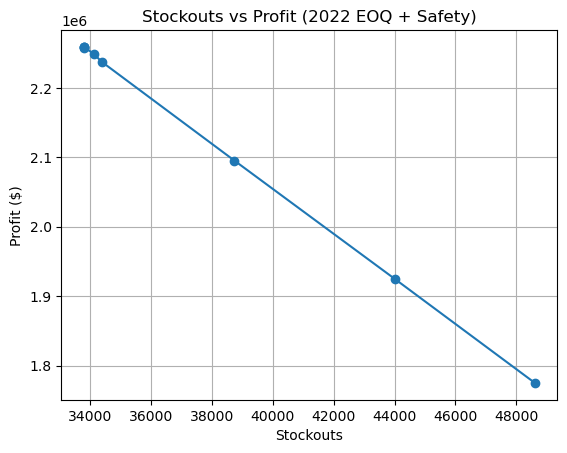

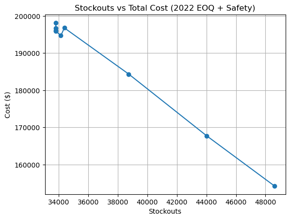

```python
def simulate_with_safety(df, eoq, safety):
    inventory = 5000
    delay = 9
    reorder_point = (eoq // 2) + safety
    pending_orders = []

    rev = hold = setup = prod = stockouts = 0

    for _, row in df.iterrows():
        date, demand = row['date'], row['total_demand']
        for d, q in [x for x in pending_orders if x[0] == date]:
            inventory += q
        pending_orders = [x for x in pending_orders if x[0] > date]

        fulfilled = min(demand, inventory)
        stockouts += max(0, demand - inventory)
        inventory -= fulfilled
        rev += fulfilled * 35.5
        hold += inventory * 0.25

        if inventory <= reorder_point and not any(x[0] > date for x in pending_orders):
            arrival = date + pd.Timedelta(days=delay)
            pending_orders.append((arrival, eoq))
            setup += 1200
            prod += eoq * 1.5

    total_cost = setup + prod + hold
    return {'safety_stock': safety, 'profit': rev - total_cost, 'cost': total_cost, 'stockouts': stockouts}


safety_levels = range(0, 2001, 250)
df_2022 = df_demand[df_demand['year'] == 2022].reset_index(drop=True)
risk_tradeoffs = [simulate_with_safety(df_2022, 1645, s) for s in safety_levels]
df_risk = pd.DataFrame(risk_tradeoffs)


import matplotlib.pyplot as plt

plt.plot(df_risk['stockouts'], df_risk['profit'], marker='o')
plt.title("Stockouts vs Profit (2022 EOQ + Safety)")
plt.xlabel("Stockouts")
plt.ylabel("Profit ($)")
plt.grid(True)
plt.show()

plt.plot(df_risk['stockouts'], df_risk['cost'], marker='o')
plt.title("Stockouts vs Total Cost (2022 EOQ + Safety)")
plt.xlabel("Stockouts")
plt.ylabel("Cost ($)")
plt.grid(True)
plt.show()
```